# Trabajo Practico Final - Modulo Ciencia de Datos I

Silvia Prevettoni

2025

El interrogante central de este trabajo practico consiste en analizar la estructura de la poblacion de origen extranjero con residencia en Argentina. Para ello, descargue la base de datos alojada en la pagina de Datos.gob.ar cuyo organismo responsable de mantenerla es la Direccion Nacional de Poblacion del Renaper.

Esta base de datos detalla la frecuencia de personas identificadas de origen extranjero residentes en Argentina desglosadas por provincia de residencia, sexo, grupo quinquenal, pais de nacimiento y nacionalidad. Los datos corresponden a Agosto 2024.

```r
#Cargando paquetes
library(readr)
library(tidyverse)
```

```r
library(ggplot2)
library(dplyr)

#Cargando la base original
base_poblacion<- read_csv("Datos/poblacion_extranjera_identificada_provincia_agosto_2024.csv")
```

**Analisis exploratorio de Datos**

```r
# conocer las primeras filas
head(base_poblacion)
```

```
## # A tibble: 6 × 7
##   pais_origen provincia_id nombre_provincia sexo  edad_quinquenal amba  cantidad
##   <chr>              <dbl> <chr>            <chr> <chr>           <chr>    <dbl>
## 1 Alemania               2 Ciudad Autónoma… F     0 a 4           AMBA         3
## 2 Alemania               2 Ciudad Autónoma… F     5 a 9           AMBA        17
## 3 Alemania               2 Ciudad Autónoma… F     10 a 14         AMBA        20
## 4 Alemania               2 Ciudad Autónoma… F     15 a 19         AMBA        26
## 5 Alemania               2 Ciudad Autónoma… F     20 a 24         AMBA        30
## 6 Alemania               2 Ciudad Autónoma… F     25 a 29         AMBA        38
```

```r
# ver la cantidad de variables y casos
dim(base_poblacion)
```

```
## [1] 14947     7
```

```r
# conocer la estructura de datos
str(base_poblacion)
```

```
## spc_tbl_ [14,947 × 7] (S3: spec_tbl_df/tbl_df/tbl/data.frame)
##  $ pais_origen     : chr [1:14947] "Alemania" "Alemania" "Alemania" "Alemania" ...
##  $ provincia_id    : num [1:14947] 2 2 2 2 2 2 2 2 2 2 ...
##  $ nombre_provincia: chr [1:14947] "Ciudad Autónoma de Buenos Aires" "Ciudad Autónoma de Buenos Aires" "Ciudad Autónoma de Buenos Aires" "Ciudad Autónoma de Buenos Aires" ...
##  $ sexo            : chr [1:14947] "F" "F" "F" "F" ...
##  $ edad_quinquenal : chr [1:14947] "0 a 4" "5 a 9" "10 a 14" "15 a 19" ...
##  $ amba            : chr [1:14947] "AMBA" "AMBA" "AMBA" "AMBA" ...
##  $ cantidad        : num [1:14947] 3 17 20 26 30 38 68 85 99 55 ...
##  - attr(*, "spec")=
##   .. cols(
##   ..   pais_origen = col_character(),
##   ..   provincia_id = col_double(),
##   ..   nombre_provincia = col_character(),
##   ..   sexo = col_character(),
##   ..   edad_quinquenal = col_character(),
##   ..   amba = col_character(),
##   ..   cantidad = col_double()
##   .. )
##  - attr(*, "problems")=<externalptr>
```

```r
#conocer el nombre de las columnas
names(base_poblacion)
```

```
## [1] "pais_origen"      "provincia_id"     "nombre_provincia" "sexo"
## [5] "edad_quinquenal"  "amba"             "cantidad"
```

```r
# chequeo de la distribucion de las variables
summary(base_poblacion)
```

```
##  pais_origen         provincia_id   nombre_provincia       sexo
##  Length:14947       Min.   : 2.00   Length:14947       Length:14947
##  Class :character   1st Qu.:18.00   Class :character   Class :character
##  Mode  :character   Median :46.00   Mode  :character   Mode  :character
##                     Mean   :45.14
##                     3rd Qu.:70.00
##                     Max.   :94.00
##  edad_quinquenal        amba              cantidad
##  Length:14947       Length:14947       Min.   :    1.0
##  Class :character   Class :character   1st Qu.:    3.0
##  Mode  :character   Mode  :character   Median :    9.0
##                                        Mean   :  165.3
##                                        3rd Qu.:   37.0
##                                        Max.   :33967.0
```

```r
#ver unicos valores de dos variables
unique(base_poblacion$pais_origen)
```

```
##  [1] "Alemania"        "Bolivia"         "Brasil"          "Chile"
##  [5] "China"           "Colombia"        "Corea del Sur"   "Cuba"
##  [9] "Ecuador"         "España"          "Estados Unidos"  "Francia"
## [13] "Italia"          "México"          "Otro país"       "Paraguay"
## [17] "Perú"            "Rep. Dominicana" "Rusia"           "Uruguay"
## [21] "Venezuela"
```

```r
unique(base_poblacion$nombre_provincia)
```

```
##  [1] "Ciudad Autónoma de Buenos Aires" "Buenos Aires"
##  [3] "Catamarca"                       "Córdoba"
##  [5] "Corrientes"                      "Chaco"
##  [7] "Chubut"                          "Entre Ríos"
##  [9] "Formosa"                         "Jujuy"
## [11] "La Pampa"                        "La Rioja"
## [13] "Mendoza"                         "Misiones"
## [15] "Neuquén"                         "Río Negro"
## [17] "Salta"                           "San Juan"
## [19] "San Luis"                        "Santa Cruz"
## [21] "Santa Fe"                        "Santiago del Estero"
## [23] "Tucumán"                         "Tierra del Fuego"
```

**Seleccion, filtrado y manipulacion de variables**

```r
#Selecciono las variables que me interesan para el proyecto
base_pob_seleccion <- base_poblacion%>%
  select(pais_origen, nombre_provincia, sexo, edad_quinquenal, cantidad)
base_pob_seleccion
```

```
## # A tibble: 14,947 × 5
##    pais_origen nombre_provincia                sexo  edad_quinquenal cantidad
##    <chr>       <chr>                           <chr> <chr>              <dbl>
##  1 Alemania    Ciudad Autónoma de Buenos Aires F     0 a 4                  3
##  2 Alemania    Ciudad Autónoma de Buenos Aires F     5 a 9                 17
##  3 Alemania    Ciudad Autónoma de Buenos Aires F     10 a 14               20
##  4 Alemania    Ciudad Autónoma de Buenos Aires F     15 a 19               26
##  5 Alemania    Ciudad Autónoma de Buenos Aires F     20 a 24               30
##  6 Alemania    Ciudad Autónoma de Buenos Aires F     25 a 29               38
##  7 Alemania    Ciudad Autónoma de Buenos Aires F     30 a 34               68
##  8 Alemania    Ciudad Autónoma de Buenos Aires F     35 a 39               85
##  9 Alemania    Ciudad Autónoma de Buenos Aires F     40 a 44               99
## 10 Alemania    Ciudad Autónoma de Buenos Aires F     45 a 49               55
## # ℹ 14,937 more rows
```

```r
#Muestra seleccionando al azar tres paises emisores y una provincia de residencia
muestra <- base_poblacion %>%
  select(pais_origen, nombre_provincia, cantidad) %>%
  filter(pais_origen %in% c("Uruguay", "Venezuela", "Cuba") & nombre_provincia=="Corrientes") %>%
  group_by(pais_origen) %>%
  summarise("total de personas" = sum(cantidad))
  print(muestra)
```

```
## # A tibble: 3 × 2
##   pais_origen `total de personas`
##   <chr>                     <dbl>
## 1 Cuba                         25
## 2 Uruguay                     743
## 3 Venezuela                   372
```

**Recodificacion mostrando re agrupamiento por zonas geograficas**

```r
# Recodificacion de provincias agrupandolas en zonas geograficas para analizar la distribucion de habitantes segun su origen
muestra_1 <- base_poblacion %>%
    select(nombre_provincia, pais_origen, cantidad) %>%
    mutate(region = case_when(nombre_provincia%in% c("Jujuy", "Salta", "Tucumán", "Catamarca", "Santiago del Estero", "La Rioja") ~ "Region Noroeste",
                              nombre_provincia %in% c("Formosa", "Chaco", "Corrientes", "Misiones") ~ "Region Noreste",
                              nombre_provincia  %in% c("Córdoba", "Entre Ríos", "La Pampa", "Santa Fe") ~ "Region Pampeana",
                              nombre_provincia  %in% c("Buenos Aires", "Ciudad Autónoma de Buenos Aires") ~ "Region AMBA",
                              nombre_provincia  %in% c("Rio Negro", "Chubut", "Santa Cruz", "Tierra del Fuego", "Neuquén") ~ "Region Patagonica",
                              nombre_provincia  %in% c("Mendoza", "San Luis", "San Juan") ~ "Region Cuyo",
                              .default = "otra provincias")) %>%
  group_by(region) %>%
  summarise("total de personas" = sum(cantidad))

muestra_1
```

```
## # A tibble: 7 × 2
##   region            `total de personas`
##   <chr>                           <dbl>
## 1 Region AMBA                   1851425
## 2 Region Cuyo                     93556
## 3 Region Noreste                 102903
## 4 Region Noroeste                 94030
## 5 Region Pampeana                152993
## 6 Region Patagonica              124846
## 7 otra provincias                 50700
```

**Cantidad y porcentaje de habitantes segun pais de origen**

```r
#Porcentaje de habitantes segun el pais de origen
base_paises <- base_poblacion %>%
  group_by(pais_origen) %>%
  summarise("poblacion" = sum(cantidad)) %>%
  arrange(-poblacion) %>%
  ungroup() %>%
  mutate(porcentaje = round(poblacion/sum(poblacion)*100, 1))

base_paises %>%
print (n= Inf)
```

```
## # A tibble: 21 × 3
##    pais_origen     poblacion porcentaje
##    <chr>               <dbl>      <dbl>
##  1 Paraguay           744306       30.1
##  2 Bolivia            542872       22
##  3 Perú               227179        9.2
##  4 Venezuela          197395        8
##  5 Chile              182173        7.4
##  6 Uruguay            111814        4.5
##  7 Brasil              76323        3.1
##  8 Italia              74311        3
##  9 Colombia            68057        2.8
## 10 Otro país           56414        2.3
## 11 España              55028        2.2
## 12 China               31946        1.3
## 13 Ecuador             27619        1.1
## 14 Estados Unidos      21723        0.9
## 15 Rep. Dominicana     10937        0.4
## 16 México               8886        0.4
## 17 Rusia                8494        0.3
## 18 Corea del Sur        7359        0.3
## 19 Francia              6104        0.2
## 20 Cuba                 5763        0.2
## 21 Alemania             5750        0.2
```

**Cantidad y porcentaje de habitantes segun provincia de residencia**

```r
# Porcentaje total de habitantes segun la provincia de residencia
base_2_provincias <- base_poblacion %>%
  group_by(nombre_provincia) %>%
  summarise("poblacion" = sum(cantidad)) %>%
  arrange(-poblacion) %>%
  ungroup() %>%
  mutate(porcentaje = round(poblacion/sum(poblacion)*100, 1))

base_2_provincias %>%
print( n= Inf)
```

```
## # A tibble: 24 × 3
##    nombre_provincia                poblacion porcentaje
##    <chr>                               <dbl>      <dbl>
##  1 Buenos Aires                      1205777       48.8
##  2 Ciudad Autónoma de Buenos Aires    645648       26.1
##  3 Córdoba                             78677        3.2
##  4 Mendoza                             76681        3.1
##  5 Misiones                            54072        2.2
##  6 Santa Fe                            52366        2.1
##  7 Río Negro                           50700        2.1
##  8 Neuquén                             46347        1.9
##  9 Salta                               39182        1.6
## 10 Chubut                              36524        1.5
## 11 Jujuy                               32058        1.3
## 12 Santa Cruz                          28085        1.1
## 13 Formosa                             26769        1.1
## 14 Entre Ríos                          17210        0.7
## 15 Corrientes                          14140        0.6
## 16 Tierra del Fuego                    13890        0.6
## 17 Tucumán                              9288        0.4
## 18 San Juan                             8693        0.4
## 19 La Rioja                             8233        0.3
## 20 San Luis                             8182        0.3
## 21 Chaco                                7922        0.3
## 22 La Pampa                             4740        0.2
## 23 Santiago del Estero                  3121        0.1
## 24 Catamarca                            2148        0.1
```

**Top 10 de paises emisores**

```r
#submuestra del top 10 de paises emisores
base_10 <- base_poblacion %>%
  group_by(pais_origen) %>%
  summarise("poblacion" = sum(cantidad)) %>%
  arrange(-poblacion) %>%
  head(10)
base_10
```

```
## # A tibble: 10 × 2
##    pais_origen poblacion
##    <chr>           <dbl>
##  1 Paraguay       744306
##  2 Bolivia        542872
##  3 Perú           227179
##  4 Venezuela      197395
##  5 Chile          182173
##  6 Uruguay        111814
##  7 Brasil          76323
##  8 Italia          74311
##  9 Colombia        68057
## 10 Otro país       56414
```

**Top 10 Provincias de Residencia**

```r
#submuestra del top 10 de provincias emisoras
base_11 <- base_poblacion %>%
  group_by(nombre_provincia) %>%
  summarise("poblacion" = sum(cantidad)) %>%
  arrange(-poblacion) %>%
head(10)
base_11
```

```
## # A tibble: 10 × 2
##    nombre_provincia                poblacion
##    <chr>                               <dbl>
##  1 Buenos Aires                      1205777
##  2 Ciudad Autónoma de Buenos Aires    645648
##  3 Córdoba                             78677
##  4 Mendoza                             76681
##  5 Misiones                            54072
##  6 Santa Fe                            52366
##  7 Río Negro                           50700
##  8 Neuquén                             46347
##  9 Salta                               39182
## 10 Chubut                              36524
```

**Visualizacion de Datos**

**Top 10 Paises Emisores**

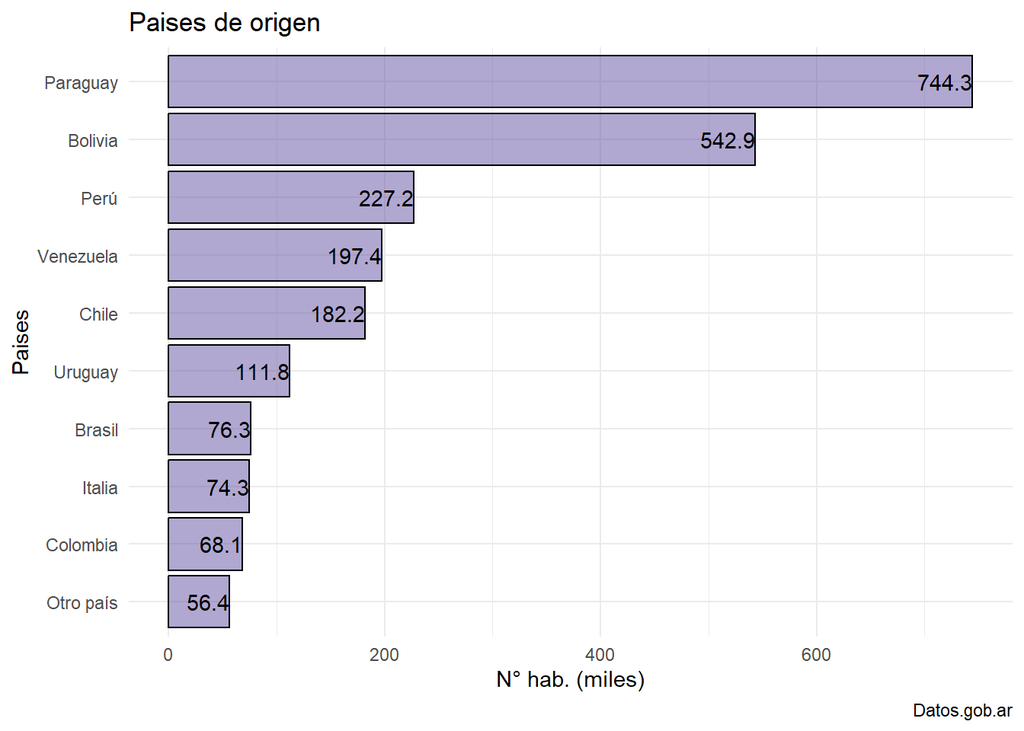

```r
# Desactivando notacion cientifica
options(scipen = 999)

# grafico mostrando los top 10 de paises emisores

ggplot(data=base_10,
       mapping = aes(x= reorder(pais_origen, poblacion),
                     y=poblacion/1000)) +
  geom_col(fill= "#6151a3",
           color = "black",
            alpha = 0.5)+
  coord_flip() +
  labs(title = "Paises de origen",
       x = "Paises",
       y = "N° hab. (miles)",
       caption = "Datos.gob.ar") +
  geom_text(aes(label = format(round(poblacion/1000, 1), nsmall = 1)),
            hjust = 1)+
theme_minimal()
```

**Top 10 Provincias de Residencia**

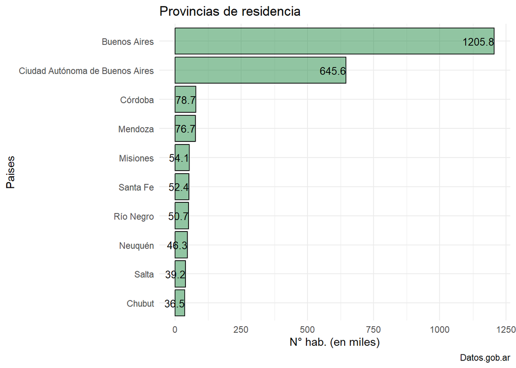

```r
#grafico mostrando los top 10 de provincias de residencia
ggplot(data=base_11,
       mapping = aes(x=reorder(nombre_provincia, poblacion),
                     y=poblacion/1000)) +
  geom_col(fill= "#238b45",
           color = "black",
           alpha = 0.5)+
  coord_flip() +
  labs(title = "Provincias de residencia",
       x = "Paises",
       y = "N° hab. (en miles)",
       caption = "Datos.gob.ar") +
  geom_text(aes(label = format(round(poblacion/1000, 1), nsmall = 1)),
            hjust = 1,
            color= "black",
            size= 3.5,
            position = position_nudge(y= -0.1)
            )+
  theme_minimal()
```

**Composicion etaria y de genero de los principales migrantes en Argentina: Paraguay, Bolivia y Peru**

**Paraguay**

```r
#tabla mostrando frecuencia etaria por edad de Paraguay
base_par <- base_poblacion %>%
  select(pais_origen, edad_quinquenal, sexo,nombre_provincia, cantidad, amba, sexo) %>%
  filter(pais_origen == "Paraguay") %>%
  group_by(edad_quinquenal, sexo) %>%
  summarise("poblacion" = sum(cantidad))
base_par %>%
  print(n=Inf)
```

```
## # A tibble: 38 × 3
## # Groups:   edad_quinquenal [18]
##    edad_quinquenal sexo  poblacion
##    <chr>           <chr>     <dbl>
##  1 0 a 4           F           847
##  2 0 a 4           M           896
##  3 10 a 14         F          5748
##  4 10 a 14         M          5835
##  5 15 a 19         F         12885
##  6 15 a 19         M         12902
##  7 20 a 24         F         23044
##  8 20 a 24         M         23477
##  9 25 a 29         F         31804
## 10 25 a 29         M         31940
## 11 25 a 29         X             3
```

[output cut: 27 more lines]

```r
#tuve que crear un vector para poder ordenar el rango etario para los siguientes graficos
edad_ordenada = c("0 a 4", "5 a 9", "10 a 14", "15 a 19", "20 a 24", "25 a 29", "30 a 34", "35 a 39","40 a 44","45 a 49","50 a 54","55 a 59","60 a 64","65 a 69","70 a 74", "75 a 79", "80 a 84", "85 +")
```

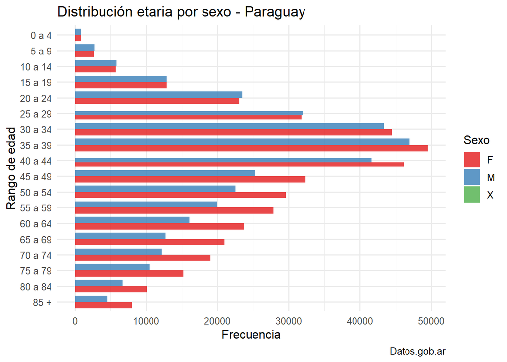

```r
#grafico representando la frecuencia etaria por sexo de Paraguay
ggplot(base_par,
       aes(x = factor(base_par$edad_quinquenal,
                      levels = edad_ordenada,
                      ordered = TRUE),
           y = poblacion,
           fill = sexo)) +
  geom_col(position = "dodge", width = 0.8, alpha = 0.8) +
  labs(title = "Distribución etaria por sexo - Paraguay",
       x = "Rango de edad",
       y = "Frecuencia",
       caption = "Datos.gob.ar",
       fill = "Sexo") +
  scale_fill_brewer(palette = "Set1") +
  coord_flip() +
  theme_minimal(base_size = 12) +
  scale_x_discrete(limits = rev)
```

**Bolivia**

```r
base_bol <- base_poblacion %>%
  select(pais_origen, edad_quinquenal, sexo,nombre_provincia, cantidad, amba, sexo) %>%
  filter(pais_origen == "Bolivia") %>%
  group_by(edad_quinquenal, sexo) %>%
  summarise("poblacion" = sum(cantidad))
base_bol %>%
  print(n=Inf)
```

```
## # A tibble: 39 × 3
## # Groups:   edad_quinquenal [18]
##    edad_quinquenal sexo  poblacion
##    <chr>           <chr>     <dbl>
##  1 0 a 4           F          1309
##  2 0 a 4           M          1359
##  3 10 a 14         F          7957
##  4 10 a 14         M          8571
##  5 15 a 19         F         11679
##  6 15 a 19         M         12095
##  7 15 a 19         X             1
##  8 20 a 24         F         18999
##  9 20 a 24         M         19145
## 10 20 a 24         X             2
## 11 25 a 29         F         25743
```

[output cut: 28 more lines]

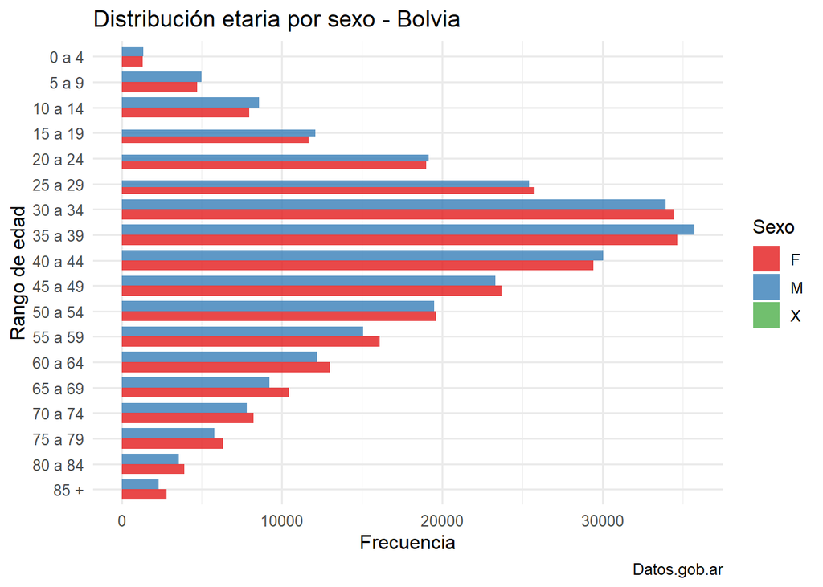

```r
#grafico representando la frecuencia etaria por sexo de Bolivia
ggplot(base_bol,
       aes(x = factor(base_bol$edad_quinquenal,
                      levels = edad_ordenada,
                      ordered = TRUE),
           y = poblacion,
           fill = sexo)) +
  geom_col(position = "dodge", width = 0.8, alpha = 0.8) +
  labs(title = "Distribución etaria por sexo - Bolvia",
       x = "Rango de edad",
       y = "Frecuencia",
       caption = "Datos.gob.ar",
       fill = "Sexo") +
  scale_fill_brewer(palette = "Set1") +
  coord_flip() +
  theme_minimal(base_size = 12) +
  scale_x_discrete(limits = rev)
```

**Peru**

```r
base_per <- base_poblacion %>%
  select(pais_origen, edad_quinquenal, sexo,nombre_provincia, cantidad, amba, sexo) %>%
  filter(pais_origen == "Perú") %>%
  group_by(edad_quinquenal, sexo) %>%
  summarise("poblacion" = sum(cantidad))
base_per %>%
  print(n=Inf)
```

```
## # A tibble: 40 × 3
## # Groups:   edad_quinquenal [18]
##    edad_quinquenal sexo  poblacion
##    <chr>           <chr>     <dbl>
##  1 0 a 4           F           260
##  2 0 a 4           M           239
##  3 10 a 14         F          1904
##  4 10 a 14         M          2077
##  5 15 a 19         F          4719
##  6 15 a 19         M          4813
##  7 15 a 19         X             2
##  8 20 a 24         F          6570
##  9 20 a 24         M          6643
## 10 20 a 24         X             3
## 11 25 a 29         F          8392
```

[output cut: 29 more lines]

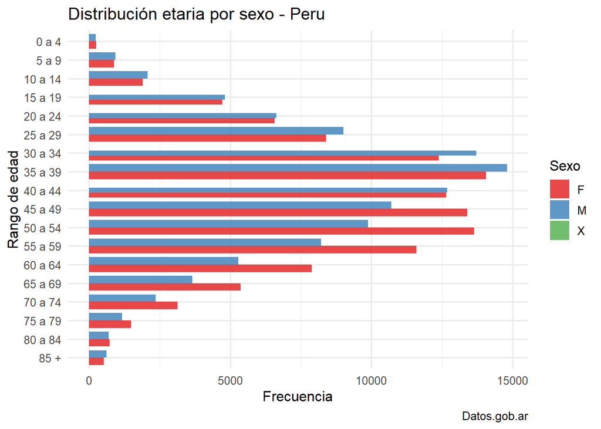

```r
#grafico representando la frecuencia etaria por sexo de Bolivia
ggplot(base_per,
       aes(x = factor(base_per$edad_quinquenal,
                      levels = edad_ordenada,
                      ordered = TRUE),
           y = poblacion,
           fill = sexo)) +
  geom_col(position = "dodge", width = 0.8, alpha = 0.8) +
  labs(title = "Distribución etaria por sexo - Peru",
       x = "Rango de edad",
       y = "Frecuencia",
       caption = "Datos.gob.ar",
       fill = "Sexo") +
  scale_fill_brewer(palette = "Set1") +
  coord_flip() +
  theme_minimal(base_size = 12) +
  scale_x_discrete(limits = rev)
```

**Conclusion**

La mayor parte de la poblacion de origen extranjero esta conformada por habitantes provenientes de Paraguay, Bolivia y Peru.

En Bolivia, el rango etario mayoritario es el de 30 a 44 y se encuentra bastante nivelado entre los sexos, si bien existe una diferencia es minima y es masculina.

Las provincias con mayor cantidad de poblacion extranjera son Buenos Aires, Ciudad Autonoma de Buenos Aires y Cordoba.

**Problemas**

Los problemas que enfrente es el ordenamiento del eje Y en los graficos de rango etario - ya que aparecia todas las etiquetas desordenadas, lo solucione creando un vector con los rangos ordenados y agregando la funcion factor y levels, tambien el orden del eje figuraba en orden descendente en vez de ascendente - lo solucione agregando > scale_x_discrete(limits = rev).

Tambien en el grafico de paises emisores/provincias de residencia tuve problemas con la visualizacion de los numeros en las barras ajustandolo con el hjust.